# Notebook slides

## Tiempos de Primera Pasada y Tiempos de Ocupación

### T2.4 · Modelado de Sistemas bajo Incertidumbre

Universidad de los Andes · Ingeniería Industrial

*Cómo calcularlos con la librería **jmarkov**, sobre matrices **explícitas** e **implícitas**.*

## Agenda

**Bloque 1 — Tiempos de primera pasada** `first_passage_time`

1. Servidor web · matriz **explícita** (pequeña, escrita a mano)
2. Paciente · matriz **explícita**
3. Call center · matriz **implícita** (creada con reglas de transición)

**Bloque 2 — Tiempos de ocupación** `occupation_time`, `absorbtion_times` 4. Servidor web · horizonte fijo 5. Reparación · hasta la primera pasada 6. Call center · horizonte fijo · matriz **implícita**

## Lo que necesitamos importar

```python
import numpy as np
import matplotlib.pyplot as plt
from jmarkov.ctmc import ctmc

AZUL, ORO, ROJO = "#1A7A9A", "#C8961E", "#C62828"  # colores MoBI
```

## La idea en una tabla

Con jmarkov solo necesitamos el generador $Q$ y llamar un método:

| Pregunta | Método de jmarkov |
| --- | --- |
| ¿Cuánto tardo en **llegar** por primera vez a un estado? | `mc.first_passage_time(destino)` |
| ¿Cuánto tiempo paso en cada estado **hasta el tiempo T**? | `mc.occupation_time(T)` |
| ¿Cuánto en cada estado **antes de quedar absorbido**? | `mc.absorbtion_times(destino, inicio)` |

La matriz $Q$ puede **escribirse a mano** (explícita) o **construirse con reglas** (implícita).

## Bloque 1 · Tiempos de primera pasada

*¿Cuánto tiempo, en promedio, hasta llegar por primera vez a un estado?*

## Ejemplo 1 · Servidor web · matriz **explícita**

```python
# Matriz explícita: filas/columnas = Normal(0), Degradado(1), Caido(2)
Q = np.array([[-0.5,  0.5,  0.0],
              [ 0.8, -1.2,  0.4],
              [ 0.0,  1.0, -1.0]])
estados = np.array(["Normal", "Degradado", "Caido"])

servidor = ctmc(Q, estados)
mfpt = servidor.first_passage_time(2).ravel()   # 2 = Caido

for estado, t in zip(["Normal", "Degradado"], mfpt):
    print(f"Desde {estado}: {t:.2f} horas hasta la primera caída")
```

```
Desde Normal: 8.50 horas hasta la primera caída
Desde Degradado: 6.50 horas hasta la primera caída
```

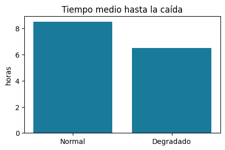

```python
plt.figure(figsize=(5, 3))
plt.bar(["Normal", "Degradado"], mfpt, color=AZUL)
plt.ylabel("horas"); plt.title("Tiempo medio hasta la caída")
plt.show()
```

## Ejemplo 2 · Paciente · matriz **explícita** (5 estados)

Gravedad de un paciente: **Estable → Leve → Moderado → Grave → UCI** (UCI es absorbente).  
**Pregunta:** ¿tiempo medio hasta requerir **UCI** desde cada estado?

```python
Q = np.array([[-0.30, 0.30, 0.00, 0.00, 0.00],
              [ 0.50,-0.95, 0.40, 0.05, 0.00],
              [ 0.00, 0.60,-1.10, 0.45, 0.05],
              [ 0.00, 0.00, 0.70,-1.30, 0.60],
              [ 0.00, 0.00, 0.00, 0.00, 0.00]])
estados = np.array(["Estable", "Leve", "Moderado", "Grave", "UCI"])

paciente = ctmc(Q, estados)
mfpt = paciente.first_passage_time(4).ravel()   # 4 = UCI

for estado, t in zip(estados[:-1], mfpt):
    print(f"Desde {estado}: {t:.1f} días hasta UCI")
```

```
Desde Estable: 25.6 días hasta UCI
Desde Leve: 22.3 días hasta UCI
Desde Moderado: 17.2 días hasta UCI
Desde Grave: 10.0 días hasta UCI
```

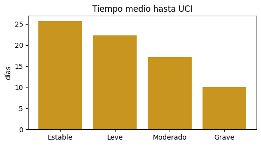

```python
plt.figure(figsize=(6, 3))
plt.bar(estados[:-1], mfpt, color=ORO)
plt.ylabel("días"); plt.title("Tiempo medio hasta UCI")
plt.show()
```

## Ejemplo 3 · Call center · matriz **implícita**

$3$ agentes, capacidad $10$, llegadas $\lambda=2.5$/min, servicio $\mu=1$/min por agente.  
**Pregunta:** ¿tiempo medio hasta **saturar** (10 llamadas) partiendo de vacío?

La matriz es 11×11: no la escribimos, la **construimos con reglas**.

```python
# Matriz implícita: la llenamos con un for según las reglas de transición
c, K, lam, mu = 3, 10, 2.5, 1.0          # agentes, capacidad, tasas
Q = np.zeros((K+1, K+1))
for i in range(K+1):
    if i < K:  Q[i, i+1] = lam            # entra una llamada
    if i > 0:  Q[i, i-1] = min(i, c) * mu  # se atiende una llamada
    Q[i, i] = -Q[i].sum()                  # la fila suma 0

call_center = ctmc(Q, np.arange(K+1))
mfpt = call_center.first_passage_time(K).ravel()   # K = 10 = saturado

print(f"Tiempo medio hasta saturar desde vacío: {mfpt[0]:.1f} min")
```

```
Tiempo medio hasta saturar desde vacío: 31.9 min
```

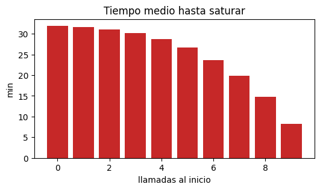

```python
plt.figure(figsize=(6, 3))
plt.bar(range(K), mfpt, color=ROJO)
plt.xlabel("llamadas al inicio"); plt.ylabel("min")
plt.title("Tiempo medio hasta saturar")
plt.show()
```

## Bloque 2 · Tiempos de ocupación

*¿Cuánto tiempo acumulado pasa el sistema en cada estado?*

## Ejemplo 4 · Servidor web en 24 h · horizonte fijo

El **mismo servidor** del Ejemplo 1.  
**Pregunta:** en un día (T = 24 h) partiendo de Normal, ¿cuántas horas pasa en cada estado? Si la hora caído cuesta \$500, ¿costo esperado por día?

```python
# Reutilizamos el servidor del Ejemplo 1
horas = servidor.occupation_time(24)[0]   # fila 0 = empezando en Normal

for estado, h in zip(["Normal", "Degradado", "Caido"], horas):
    print(f"{estado}: {h:.2f} h/día")
print(f"Costo de indisponibilidad: {horas[2]*500:.0f} $/día")
```

```
Normal: 13.31 h/día
Degradado: 7.73 h/día
Caido: 2.96 h/día
Costo de indisponibilidad: 1480 $/día
```

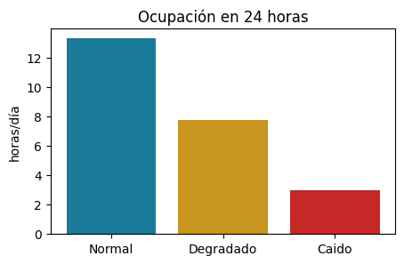

```python
plt.figure(figsize=(5, 3))
plt.bar(["Normal", "Degradado", "Caido"], horas, color=[AZUL, ORO, ROJO])
plt.ylabel("horas/día"); plt.title("Ocupación en 24 horas")
plt.show()
```

## Ejemplo 5 · Reparación · ocupación **hasta la primera pasada**

Fases hasta volver a operar: **Diag → Espera → Repara → Prueba → Operativa** (Operativa es absorbente; desde Prueba a veces se reincide a Diag).  
**Pregunta:** antes de volver a **Operativa**, ¿cuánto tiempo se pasa en cada fase?

```python
Q = np.array([[-1.0, 0.7, 0.3, 0.0, 0.0],
              [ 0.0,-0.5, 0.5, 0.0, 0.0],
              [ 0.0, 0.0,-0.8, 0.8, 0.0],
              [ 0.2, 0.0, 0.0,-1.0, 0.8],
              [ 0.0, 0.0, 0.0, 0.0, 0.0]])
estados = np.array(["Diag", "Espera", "Repara", "Prueba", "Operativa"])
reparacion = ctmc(Q, estados)

fases = ["Diag", "Espera", "Repara", "Prueba"]
tiempos = [reparacion.absorbtion_times(f, "Diag").item() for f in fases]

for f, t in zip(fases, tiempos):
    print(f"{f}: {t:.2f} h")
print(f"Suma = tiempo total hasta reparar = {sum(tiempos):.2f} h")
```

```
Diag: 1.25 h
Espera: 1.75 h
Repara: 1.56 h
Prueba: 1.25 h
Suma = tiempo total hasta reparar = 5.81 h
```

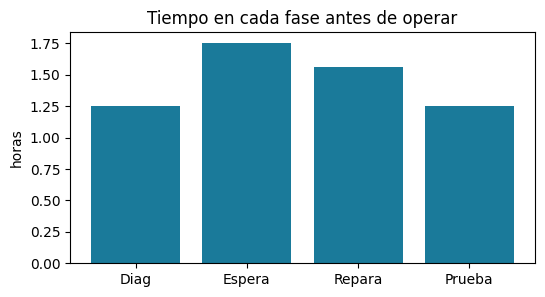

```python
plt.figure(figsize=(6, 3))
plt.bar(fases, tiempos, color=AZUL)
plt.ylabel("horas"); plt.title("Tiempo en cada fase antes de operar")
plt.show()
```

## Ejemplo 6 · Call center en un turno · matriz **implícita**

El **mismo call center** del Ejemplo 3, turno de 8 h = 480 min, inicia vacío.  
**Pregunta:** ¿cuántos minutos hay los **3 agentes ocupados** (estados ≥ 3) y cuántos en **bloqueo** (lleno)?

```python
# Reutilizamos el call center del Ejemplo 3 (matriz implícita)
ocupacion = call_center.occupation_time(480)[0]   # 480 min, desde vacío

print(f"Minutos con los 3 agentes ocupados (estados >= 3): {ocupacion[3:].sum():.0f}")
print(f"Minutos en bloqueo (sistema lleno):                {ocupacion[10]:.0f}")
```

```
Minutos con los 3 agentes ocupados (estados >= 3): 308
Minutos en bloqueo (sistema lleno):                18
```

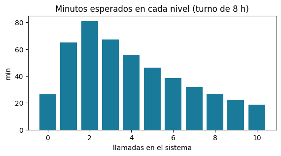

```python
plt.figure(figsize=(6.5, 3))
plt.bar(range(11), ocupacion, color=AZUL)
plt.xlabel("llamadas en el sistema"); plt.ylabel("min")
plt.title("Minutos esperados en cada nivel (turno de 8 h)")
plt.show()
```

## Resumen · qué método usar

| Pregunta | Método | Ejemplos |
| --- | --- | --- |
| ¿Cuánto tardo en llegar a un estado? | `first_passage_time(destino)` | 1, 2, 3 |
| ¿Cuánto tiempo paso en cada estado hasta T? | `occupation_time(T)` | 4, 6 |
| ¿Cuánto en cada estado antes de absorberme? | `absorbtion_times(destino, inicio)` | 5 |

La matriz puede ser **explícita** (escrita a mano) o **implícita** (con reglas): jmarkov funciona igual.

## Conclusiones

- Con un generador $Q$ y un método, jmarkov responde las tres preguntas.
- **Explícita**: escribimos la matriz pequeña a mano (ej. 1, 2, 4, 5).
- **Implícita**: la llenamos con un `for` de reglas, útil cuando es grande (ej. 3 y 6: 11×11 sin escribir 121 números).
- Mismo modelo, distintas preguntas: el servidor y el call center se reusaron para ocupación.

**Próximo tema:** análisis de salida — estimar estas métricas cuando el modelo es muy grande para resolverlo exacto.